# Covid19

Brandon Khuu

2024-06-28

Import the data

```r
# github link
url_in = "https://raw.githubusercontent.com/CSSEGISandData/COVID-19/master/csse_covid_19_data/csse_covid_19_time_series/"

#  the csv files
file_names = c("time_series_covid19_confirmed_global.csv", "time_series_covid19_deaths_global.csv", "time_series_covid19_deaths_US.csv", "time_series_covid19_confirmed_US.csv")

# Import data
urls = str_c(url_in, file_names)
urls
```

```
## [1] "https://raw.githubusercontent.com/CSSEGISandData/COVID-19/master/csse_covid_19_data/csse_covid_19_time_series/time_series_covid19_confirmed_global.csv"
## [2] "https://raw.githubusercontent.com/CSSEGISandData/COVID-19/master/csse_covid_19_data/csse_covid_19_time_series/time_series_covid19_deaths_global.csv"
## [3] "https://raw.githubusercontent.com/CSSEGISandData/COVID-19/master/csse_covid_19_data/csse_covid_19_time_series/time_series_covid19_deaths_US.csv"
## [4] "https://raw.githubusercontent.com/CSSEGISandData/COVID-19/master/csse_covid_19_data/csse_covid_19_time_series/time_series_covid19_confirmed_US.csv"
```

Print Overview of each table

```r
us_cases = read_csv(urls[3])
us_deaths = read_csv(urls[4])
```

```r
head(us_cases)
```

```
## # A tibble: 6 × 1,155
##        UID iso2  iso3  code3  FIPS Admin2  Province_State Country_Region   Lat
##      <dbl> <chr> <chr> <dbl> <dbl> <chr>   <chr>          <chr>          <dbl>
## 1 84001001 US    USA     840  1001 Autauga Alabama        US              32.5
## 2 84001003 US    USA     840  1003 Baldwin Alabama        US              30.7
## 3 84001005 US    USA     840  1005 Barbour Alabama        US              31.9
## 4 84001007 US    USA     840  1007 Bibb    Alabama        US              33.0
## 5 84001009 US    USA     840  1009 Blount  Alabama        US              34.0
## 6 84001011 US    USA     840  1011 Bullock Alabama        US              32.1
## # ℹ 1,146 more variables: Long_ <dbl>, Combined_Key <chr>, Population <dbl>,
## #   `1/22/20` <dbl>, `1/23/20` <dbl>, `1/24/20` <dbl>, `1/25/20` <dbl>,
## #   `1/26/20` <dbl>, `1/27/20` <dbl>, `1/28/20` <dbl>, `1/29/20` <dbl>,
## #   `1/30/20` <dbl>, `1/31/20` <dbl>, `2/1/20` <dbl>, `2/2/20` <dbl>,
## #   `2/3/20` <dbl>, `2/4/20` <dbl>, `2/5/20` <dbl>, `2/6/20` <dbl>,
## #   `2/7/20` <dbl>, `2/8/20` <dbl>, `2/9/20` <dbl>, `2/10/20` <dbl>,
## #   `2/11/20` <dbl>, `2/12/20` <dbl>, `2/13/20` <dbl>, `2/14/20` <dbl>, …
```

```r
head(us_deaths)
```

```
## # A tibble: 6 × 1,154
##        UID iso2  iso3  code3  FIPS Admin2  Province_State Country_Region   Lat
##      <dbl> <chr> <chr> <dbl> <dbl> <chr>   <chr>          <chr>          <dbl>
## 1 84001001 US    USA     840  1001 Autauga Alabama        US              32.5
## 2 84001003 US    USA     840  1003 Baldwin Alabama        US              30.7
## 3 84001005 US    USA     840  1005 Barbour Alabama        US              31.9
## 4 84001007 US    USA     840  1007 Bibb    Alabama        US              33.0
## 5 84001009 US    USA     840  1009 Blount  Alabama        US              34.0
## 6 84001011 US    USA     840  1011 Bullock Alabama        US              32.1
## # ℹ 1,145 more variables: Long_ <dbl>, Combined_Key <chr>, `1/22/20` <dbl>,
## #   `1/23/20` <dbl>, `1/24/20` <dbl>, `1/25/20` <dbl>, `1/26/20` <dbl>,
## #   `1/27/20` <dbl>, `1/28/20` <dbl>, `1/29/20` <dbl>, `1/30/20` <dbl>,
## #   `1/31/20` <dbl>, `2/1/20` <dbl>, `2/2/20` <dbl>, `2/3/20` <dbl>,
## #   `2/4/20` <dbl>, `2/5/20` <dbl>, `2/6/20` <dbl>, `2/7/20` <dbl>,
## #   `2/8/20` <dbl>, `2/9/20` <dbl>, `2/10/20` <dbl>, `2/11/20` <dbl>,
## #   `2/12/20` <dbl>, `2/13/20` <dbl>, `2/14/20` <dbl>, `2/15/20` <dbl>, …
```

Preprocess and clean the tables for the columns that we will be working with

```r
# Pivot wide-format data for dates and sum totals for each state

cases = us_cases %>%
  pivot_longer(cols = 13:ncol(us_cases), names_to = "date") %>%
  group_by(`Province_State`, date) %>%
  summarise("cum_cases" = sum(value, na.rm = TRUE), .groups = 'drop')

deaths = us_deaths %>%
  pivot_longer(cols = 13:ncol(us_deaths), names_to = "date") %>%
  group_by(`Province_State`, date) %>%
  summarise("cum_deaths" = sum(value, na.rm = TRUE), .groups = 'drop')
```

Adjust the date from character string to date object

```r
# Convert dates to datetime object
cases$date = lubridate::mdy(cases$date)
deaths$date = lubridate::mdy(deaths$date)

# Rename columns from Province_State -> State & Admin2 -> County
cases = cases %>%
  rename_at('Province_State', ~'State')
deaths = deaths %>%
  rename_at('Province_State', ~'State')

# check global deaths and cases data
head(cases)
```

```
## # A tibble: 6 × 3
##   State   date       cum_cases
##   <chr>   <date>         <dbl>
## 1 Alabama 2021-01-01      4872
## 2 Alabama 2022-01-01     16455
## 3 Alabama 2023-01-01     20737
## 4 Alabama 2021-01-10      5334
## 5 Alabama 2022-01-10     16624
## 6 Alabama 2023-01-10     20776
```

```r
head(deaths)
```

```
## # A tibble: 6 × 3
##   State   date       cum_deaths
##   <chr>   <date>          <dbl>
## 1 Alabama 2021-01-01     365747
## 2 Alabama 2022-01-01     896614
## 3 Alabama 2023-01-01    1568934
## 4 Alabama 2021-01-10     401900
## 5 Alabama 2022-01-10     984882
## 6 Alabama 2023-01-10    1587224
```

Look for the states with the highest number of caeses and deaths to do analysis

```r
top_cases <- cases %>%
  group_by(State) %>%
  summarise(cum_cases = max(cum_cases, na.rm = TRUE))

top_deaths <- deaths %>%
  group_by(State) %>%
  summarise(cum_deaths = max(cum_deaths, na.rm = TRUE))

top5cases <- top_cases %>%
  arrange(desc(cum_cases)) %>%
  slice_head(n=5)

top5deaths <- top_deaths %>%
  arrange(desc(cum_deaths)) %>%
  slice_head(n=5)

print(top5cases)
```

```
## # A tibble: 5 × 2
##   State        cum_cases
##   <chr>            <dbl>
## 1 California      101159
## 2 Texas            93390
## 3 Florida          86850
## 4 New York         77157
## 5 Pennsylvania     50398
```

```r
print(top5deaths)
```

```
## # A tibble: 5 × 2
##   State      cum_deaths
##   <chr>           <dbl>
## 1 California   12129699
## 2 Texas         8466220
## 3 Florida       7574590
## 4 New York      6794738
## 5 Illinois      4083292
```

Create us_all and the split by target states

```r
# merge global data sets and filter to get data just for Switzerland and for germany
us_all = merge(x=deaths, y=cases, all.x=TRUE)
CA <- us_all[us_all$State == "California", ]
TX <- us_all[us_all$State == "Texas", ]
FL <- us_all[us_all$State == "Florida", ]
NY <- us_all[us_all$State == "New York", ]
IL <- us_all[us_all$State == "Illinois", ]
PA <- us_all[us_all$State == "Pennsylvania", ]

# View first several lines of each data set

head(CA)
```

```
##           State       date cum_deaths cum_cases
## 5711 California 2020-01-23          0         0
## 5712 California 2020-01-24          0         0
## 5713 California 2020-01-25          0         0
## 5714 California 2020-01-26          2         0
## 5715 California 2020-01-27          2         0
## 5716 California 2020-01-28          2         0
```

```r
head(TX)
```

```
##       State       date cum_deaths cum_cases
## 55959 Texas 2020-01-23          0         0
## 55960 Texas 2020-01-24          0         0
## 55961 Texas 2020-01-25          0         0
## 55962 Texas 2020-01-26          0         0
## 55963 Texas 2020-01-27          0         0
## 55964 Texas 2020-01-28          0         0
```

```r
head(FL)
```

```
##         State       date cum_deaths cum_cases
## 12563 Florida 2020-01-23          0         0
## 12564 Florida 2020-01-24          0         0
## 12565 Florida 2020-01-25          0         0
## 12566 Florida 2020-01-26          0         0
## 12567 Florida 2020-01-27          0         0
## 12568 Florida 2020-01-28          0         0
```

```r
head(NY)
```

```
##          State       date cum_deaths cum_cases
## 41113 New York 2020-01-23          0         0
## 41114 New York 2020-01-24          0         0
## 41115 New York 2020-01-25          0         0
## 41116 New York 2020-01-26          0         0
## 41117 New York 2020-01-27          0         0
## 41118 New York 2020-01-28          0         0
```

```r
head(IL)
```

```
##          State       date cum_deaths cum_cases
## 19415 Illinois 2020-01-23          0         0
## 19416 Illinois 2020-01-24          1         0
## 19417 Illinois 2020-01-25          1         0
## 19418 Illinois 2020-01-26          1         0
## 19419 Illinois 2020-01-27          1         0
## 19420 Illinois 2020-01-28          1         0
```

```r
head(PA)
```

```
##              State       date cum_deaths cum_cases
## 49107 Pennsylvania 2020-01-23          0         0
## 49108 Pennsylvania 2020-01-24          0         0
## 49109 Pennsylvania 2020-01-25          0         0
## 49110 Pennsylvania 2020-01-26          0         0
## 49111 Pennsylvania 2020-01-27          0         0
## 49112 Pennsylvania 2020-01-28          0         0
```

Adjust the values in the columns based on state popululation. (per capita) [State populations from: [https://worldpopulationreview.com/states]

```r
# Adding a per capita column to both data sets and viewing their summaries
CA_cap <- CA %>%
  mutate(
    CA_cases_per_capita = cum_cases / 38889770,
    CA_deaths_per_capita = cum_deaths / 38889770,
  )


TX_cap <- TX %>%
  mutate(
    TX_cases_per_capita = cum_cases / 30976754,
    TX_deaths_per_capita = cum_deaths / 30976754
  )

FL_cap <- FL %>%
  mutate(
    FL_cases_per_capita = cum_cases / 22975931,
    FL_deaths_per_capita = cum_deaths / 22975931
  )


NY_cap <- NY %>%
  mutate(
    NY_cases_per_capita = cum_cases / 19469232,
    NY_deaths_per_capita = cum_deaths / 19469232
  )

IL_cap <- IL %>%
  mutate(
    IL_cases_per_capita = cum_cases / 12516863,
    IL_deaths_per_capita = cum_deaths / 12516863
  )

PA_cap <- PA %>%
  mutate(
    PA_cases_per_capita = cum_cases / 12516863,
    PA_deaths_per_capita = cum_deaths / 12516863
  )
```

Print smmary of each state to get an overview of each dataframe

```r
summary(CA_cap)
```

```
##     State                date              cum_deaths         cum_cases
##  Length:1142        Min.   :2020-01-23   Min.   :       0   Min.   :     0
##  Class :character   1st Qu.:2020-11-03   1st Qu.:  955988   1st Qu.: 17756
##  Mode  :character   Median :2021-08-15   Median : 4232962   Median : 64360
##                     Mean   :2021-08-15   Mean   : 5399466   Mean   : 57347
##                     3rd Qu.:2022-05-27   3rd Qu.: 9561391   3rd Qu.: 91209
##                     Max.   :2023-03-09   Max.   :12129699   Max.   :101159
##  CA_cases_per_capita CA_deaths_per_capita
##  Min.   :0.0000000   Min.   :0.00000
##  1st Qu.:0.0004566   1st Qu.:0.02458
##  Median :0.0016549   Median :0.10885
##  Mean   :0.0014746   Mean   :0.13884
##  3rd Qu.:0.0023453   3rd Qu.:0.24586
##  Max.   :0.0026012   Max.   :0.31190
```

```r
summary(TX_cap)
```

```
##     State                date              cum_deaths        cum_cases
##  Length:1142        Min.   :2020-01-23   Min.   :      0   Min.   :    0
##  Class :character   1st Qu.:2020-11-03   1st Qu.: 950509   1st Qu.:19170
##  Mode  :character   Median :2021-08-15   Median :3376964   Median :54302
##                     Mean   :2021-08-15   Mean   :3998719   Mean   :53680
##                     3rd Qu.:2022-05-27   3rd Qu.:6910483   3rd Qu.:88155
##                     Max.   :2023-03-09   Max.   :8466220   Max.   :93390
##  TX_cases_per_capita TX_deaths_per_capita
##  Min.   :0.0000000   Min.   :0.00000
##  1st Qu.:0.0006189   1st Qu.:0.03068
##  Median :0.0017530   Median :0.10902
##  Mean   :0.0017329   Mean   :0.12909
##  3rd Qu.:0.0028458   3rd Qu.:0.22309
##  Max.   :0.0030148   Max.   :0.27331
```

```r
summary(FL_cap)
```

```
##     State                date              cum_deaths        cum_cases
##  Length:1142        Min.   :2020-01-23   Min.   :      0   Min.   :    0
##  Class :character   1st Qu.:2020-11-03   1st Qu.: 817806   1st Qu.:16898
##  Mode  :character   Median :2021-08-15   Median :2927089   Median :40945
##                     Mean   :2021-08-15   Mean   :3483676   Mean   :45075
##                     3rd Qu.:2022-05-27   3rd Qu.:6125115   3rd Qu.:74466
##                     Max.   :2023-03-09   Max.   :7574590   Max.   :86850
##  FL_cases_per_capita FL_deaths_per_capita
##  Min.   :0.0000000   Min.   :0.00000
##  1st Qu.:0.0007355   1st Qu.:0.03559
##  Median :0.0017821   Median :0.12740
##  Mean   :0.0019618   Mean   :0.15162
##  3rd Qu.:0.0032410   3rd Qu.:0.26659
##  Max.   :0.0037800   Max.   :0.32967
```

```r
summary(NY_cap)
```

```
##     State                date              cum_deaths        cum_cases
##  Length:1142        Min.   :2020-01-23   Min.   :      0   Min.   :    0
##  Class :character   1st Qu.:2020-11-03   1st Qu.: 518339   1st Qu.:33608
##  Mode  :character   Median :2021-08-15   Median :2207818   Median :53885
##                     Mean   :2021-08-15   Mean   :2970234   Mean   :50894
##                     3rd Qu.:2022-05-27   3rd Qu.:5414434   3rd Qu.:68955
##                     Max.   :2023-03-09   Max.   :6794738   Max.   :77157
##  NY_cases_per_capita NY_deaths_per_capita
##  Min.   :0.000000    Min.   :0.00000
##  1st Qu.:0.001726    1st Qu.:0.02662
##  Median :0.002768    Median :0.11340
##  Mean   :0.002614    Mean   :0.15256
##  3rd Qu.:0.003542    3rd Qu.:0.27810
##  Max.   :0.003963    Max.   :0.34900
```

```r
summary(IL_cap)
```

```
##     State                date              cum_deaths        cum_cases
##  Length:1142        Min.   :2020-01-23   Min.   :      0   Min.   :    0
##  Class :character   1st Qu.:2020-11-03   1st Qu.: 438150   1st Qu.:10175
##  Mode  :character   Median :2021-08-15   Median :1462254   Median :26108
##                     Mean   :2021-08-15   Mean   :1858354   Mean   :24729
##                     3rd Qu.:2022-05-27   3rd Qu.:3286381   3rd Qu.:38127
##                     Max.   :2023-03-09   Max.   :4083292   Max.   :41496
##  IL_cases_per_capita IL_deaths_per_capita
##  Min.   :0.0000000   Min.   :0.0000
##  1st Qu.:0.0008129   1st Qu.:0.0350
##  Median :0.0020858   Median :0.1168
##  Mean   :0.0019756   Mean   :0.1485
##  3rd Qu.:0.0030461   3rd Qu.:0.2626
##  Max.   :0.0033152   Max.   :0.3262
```

```r
summary(PA_cap)
```

```
##     State                date              cum_deaths        cum_cases
##  Length:1142        Min.   :2020-01-23   Min.   :      0   Min.   :    0
##  Class :character   1st Qu.:2020-11-03   1st Qu.: 221142   1st Qu.: 8850
##  Mode  :character   Median :2021-08-15   Median :1266163   Median :27966
##                     Mean   :2021-08-15   Mean   :1608447   Mean   :27944
##                     3rd Qu.:2022-05-27   3rd Qu.:2907324   3rd Qu.:45147
##                     Max.   :2023-03-09   Max.   :3527854   Max.   :50398
##  PA_cases_per_capita PA_deaths_per_capita
##  Min.   :0.0000000   Min.   :0.00000
##  1st Qu.:0.0007071   1st Qu.:0.01767
##  Median :0.0022343   Median :0.10116
##  Mean   :0.0022325   Mean   :0.12850
##  3rd Qu.:0.0036069   3rd Qu.:0.23227
##  Max.   :0.0040264   Max.   :0.28185
```

Merge the individual state dataframes into 1 single dataframe

```r
merged_CA_TX <- merge(CA_cap,TX_cap, by = "date", all = TRUE, suffixes = c(".CA", ".TX"))
merged_CA_TX_FL <- merge(merged_CA_TX,FL_cap, by = "date", all = TRUE, suffixes = c("", "FL"))
merged_CA_TX_FL_NY <- merge(merged_CA_TX_FL,NY_cap, by = "date", all = TRUE, suffixes = c("", "NY"))
merged_CA_TX_FL_NY_PA <- merge(merged_CA_TX_FL_NY,PA_cap, by = "date", all = TRUE, suffixes = c("", "PA"))
all_merge <- merge(merged_CA_TX_FL_NY_PA,IL_cap, by = "date", all = TRUE, suffixes = c("", "IL"))
```

Plot the cases per capita and deaths per capita

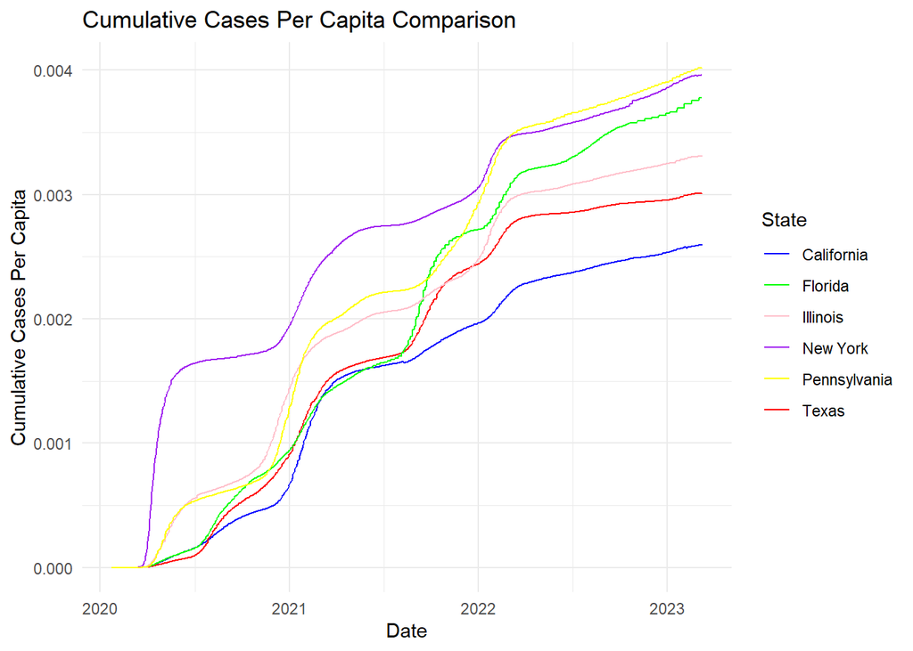

```r
# Create line plots for cases per capita
ggplot(all_merge, aes(x = date)) +
  geom_line(aes(y = CA_cases_per_capita, color = "California", linetype = "California")) +
  geom_line(aes(y = TX_cases_per_capita, color = "Texas", linetype = "Texas")) +
  geom_line(aes(y = FL_cases_per_capita, color = "Florida", linetype = "Florida")) +
  geom_line(aes(y = NY_cases_per_capita, color = "New York", linetype = "New York")) +
  geom_line(aes(y = IL_cases_per_capita, color = "Illinois", linetype = "Illinois")) +
  geom_line(aes(y = PA_cases_per_capita, color = "Pennsylvania", linetype = "Pennsylvania")) +
  labs(title = "Cumulative Cases Per Capita Comparison",
       x = "Date",
       y = "Cumulative Cases Per Capita",
       color = "State",
       linetype = "State") +
  scale_color_manual(values = c("California" = "blue",
                                "Texas" = "red",
                                "Florida" = "green",
                                "New York" = "purple",
                                "Illinois" = "pink",
                                "Pennsylvania" = "yellow")) +
  scale_linetype_manual(values = c("California" = "solid",
                                   "Texas" = "solid",
                                   "Florida" = "solid",
                                   "New York" = "solid",
                                   "Illinois" = "solid",
                                   "Pennsylvania" = "solid")) +
  theme_minimal()
```

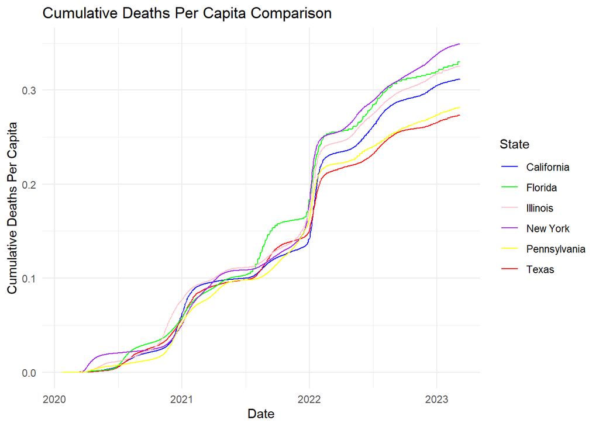

```r
# Create line plots for deaths per capita
ggplot(all_merge, aes(x = date)) +
  geom_line(aes(y = CA_deaths_per_capita, color = "California", linetype = "California")) +
  geom_line(aes(y = TX_deaths_per_capita, color = "Texas", linetype = "Texas")) +
  geom_line(aes(y = FL_deaths_per_capita, color = "Florida", linetype = "Florida")) +
  geom_line(aes(y = NY_deaths_per_capita, color = "New York", linetype = "New York")) +
  geom_line(aes(y = IL_deaths_per_capita, color = "Illinois", linetype = "Illinois")) +
  geom_line(aes(y = PA_deaths_per_capita, color = "Pennsylvania", linetype = "Pennsylvania")) +
  labs(title = "Cumulative Deaths Per Capita Comparison",
       x = "Date",
       y = "Cumulative Deaths Per Capita",
       color = "State",
       linetype = "State") +
  scale_color_manual(values = c("California" = "blue",
                                "Texas" = "red",
                                "Florida" = "green",
                                "New York" = "purple",
                                "Illinois" = "pink",
                                "Pennsylvania" = "yellow")) +
  scale_linetype_manual(values = c("California" = "solid",
                                   "Texas" = "solid",
                                   "Florida" = "solid",
                                   "New York" = "solid",
                                   "Illinois" = "solid",
                                   "Pennsylvania" = "solid")) +
  theme_minimal()
```

Create columnn deaths per case

```r
CA$deaths_per_case <- ifelse(CA$cum_cases > 0,CA$cum_deaths / CA$cum_cases,0)
TX$deaths_per_case <- ifelse(TX$cum_cases > 0,TX$cum_deaths / TX$cum_cases,0)
FL$deaths_per_case <- ifelse(FL$cum_cases > 0,FL$cum_deaths / FL$cum_cases,0)
NY$deaths_per_case <- ifelse(NY$cum_cases > 0,NY$cum_deaths / NY$cum_cases,0)
IL$deaths_per_case <- ifelse(IL$cum_cases > 0,IL$cum_deaths / IL$cum_cases,0)
PA$deaths_per_case <- ifelse(PA$cum_cases > 0,PA$cum_deaths / PA$cum_cases,0)
```

Plot deaths per case to view deaths over time

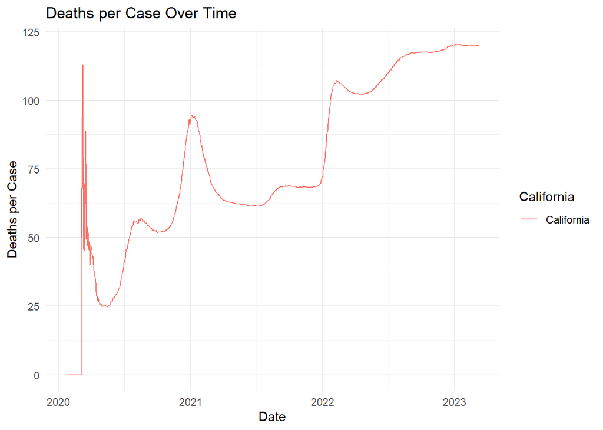

```r
ggplot(CA, aes(x = date, y = deaths_per_case, color = "California")) +
  geom_line() +
  labs(title = "Deaths per Case Over Time",
       x = "Date",
       y = "Deaths per Case",
       color = "California") +
  theme_minimal()
```

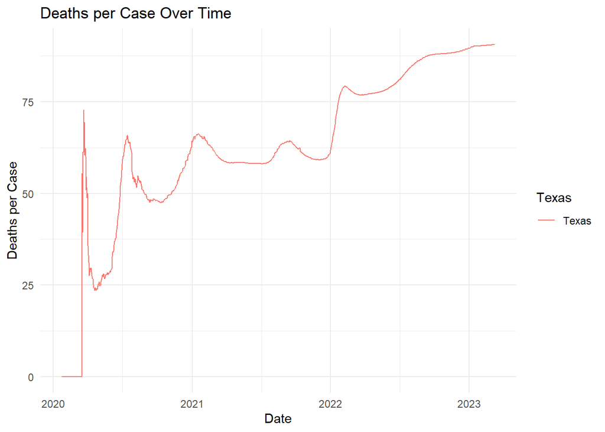

```r
ggplot(TX, aes(x = date, y = deaths_per_case, color = "Texas")) +
  geom_line() +
  labs(title = "Deaths per Case Over Time",
       x = "Date",
       y = "Deaths per Case",
       color = "Texas") +
  theme_minimal()
```

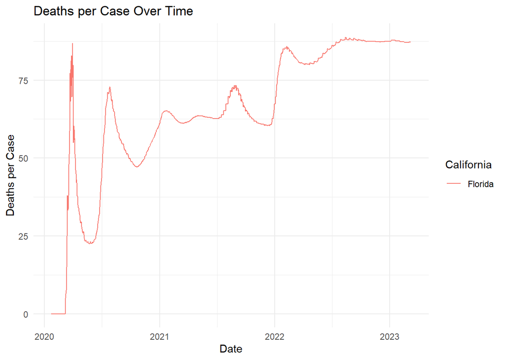

```r
ggplot(FL, aes(x = date, y = deaths_per_case, color = "Florida")) +
  geom_line() +
  labs(title = "Deaths per Case Over Time",
       x = "Date",
       y = "Deaths per Case",
       color = "California") +
  theme_minimal()
```

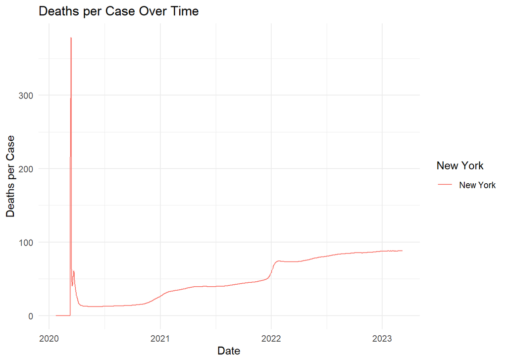

```r
ggplot(NY, aes(x = date, y = deaths_per_case, color = "New York")) +
  geom_line() +
  labs(title = "Deaths per Case Over Time",
       x = "Date",
       y = "Deaths per Case",
       color = "New York") +
  theme_minimal()
```

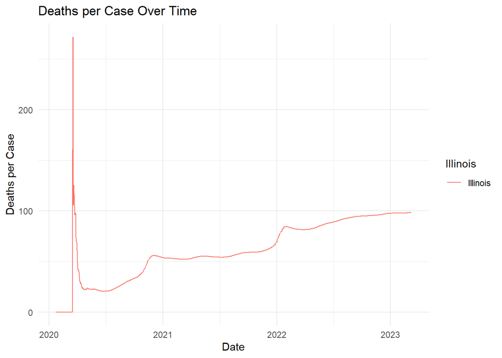

```r
ggplot(IL, aes(x = date, y = deaths_per_case, color = "Illinois")) +
  geom_line() +
  labs(title = "Deaths per Case Over Time",
       x = "Date",
       y = "Deaths per Case",
       color = "Illinois") +
  theme_minimal()
```

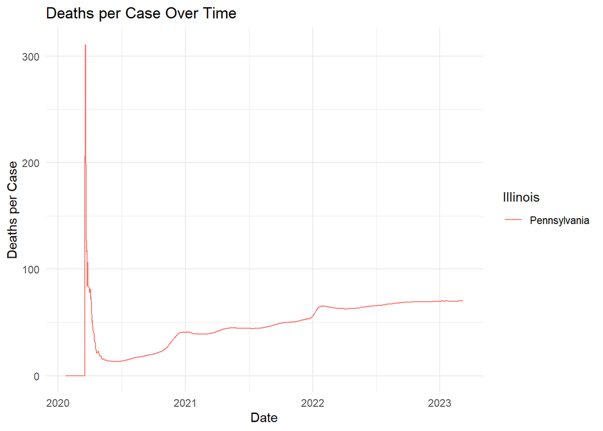

```r
ggplot(PA, aes(x = date, y = deaths_per_case, color = "Pennsylvania")) +
  geom_line() +
  labs(title = "Deaths per Case Over Time",
       x = "Date",
       y = "Deaths per Case",
       color = "Illinois") +
  theme_minimal()
```

Merge each state dataframe to view on a single graph

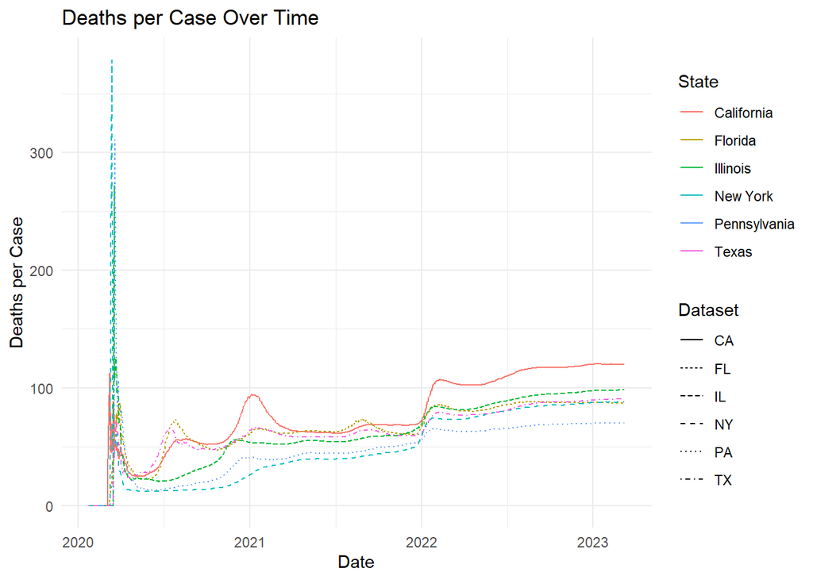

```r
merged_states_count <- rbind(transform(CA, dataset = "CA"),
                             transform(TX, dataset = "TX"),
                             transform(FL, dataset = "FL"),
                             transform(NY, dataset = "NY"),
                             transform(IL, dataset = "IL"),
                             transform(PA, dataset = "PA"))

ggplot(merged_states_count, aes(x = date, y = deaths_per_case, color = State, linetype = dataset)) +
  geom_line() +
  labs(title = "Deaths per Case Over Time",
       x = "Date",
       y = "Deaths per Case",
       color = "State",
       linetype = "Dataset") +
  theme_minimal()
```

State predictor model with random forest. Principal Compnent Analysis(PCA) was used as the target feature to aggregate all 6 deaths per capita to maintain the variability

```r
X <- all_merge[, c('CA_cases_per_capita', 'TX_cases_per_capita',
                   'FL_cases_per_capita', 'NY_cases_per_capita',
                   'IL_cases_per_capita', 'PA_cases_per_capita')]

pca <- prcomp(all_merge[, c('CA_deaths_per_capita', 'TX_deaths_per_capita',
                            'FL_deaths_per_capita', 'NY_deaths_per_capita',
                            'IL_deaths_per_capita','PA_deaths_per_capita')], scale = TRUE)

all_merge$pca_deaths_per_capita <- pca$x[,1]
y <- all_merge$pca_deaths_per_capita
```

Split data into train/test set using seed 123

```r
set.seed(123)
trainIndex <- createDataPartition(y, p = .8, list = FALSE, times = 1)
X_train <- X[trainIndex,]
X_test <- X[-trainIndex,]
y_train <- y[trainIndex]
y_test <- y[-trainIndex]
rf_model <- randomForest(X_train, y_train, ntree = 100)
```

Predictions form the model and scoring with Mean Squarred Error(MSE)

```r
y_pred <- predict(rf_model, X_test)
mse <- mean((y_test - y_pred)^2)
print(paste('Mean Squared Error:', mse))
```

```
## [1] "Mean Squared Error: 3.70073766305327e-05"
```

```r
print(importance(rf_model))
```

```
##                     IncNodePurity
## CA_cases_per_capita      964.0545
## TX_cases_per_capita      854.8148
## FL_cases_per_capita      509.8011
## NY_cases_per_capita     1223.4759
## IL_cases_per_capita      874.9129
## PA_cases_per_capita     1026.8634
```

Graph Node Purity to see which column had the most influnce on the model

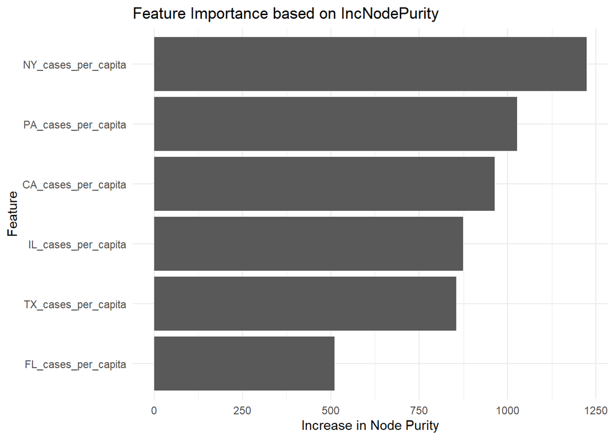

```r
importance_df <- as.data.frame(importance(rf_model))
importance_df$Feature <- rownames(importance_df)

# Create a bar plot
ggplot(importance_df, aes(x = reorder(Feature, IncNodePurity), y = IncNodePurity)) +
  geom_bar(stat = "identity") +
  coord_flip() +
  xlab("Feature") +
  ylab("Increase in Node Purity") +
  ggtitle("Feature Importance based on IncNodePurity") +
  theme_minimal()
```